## Calculating densities from quantiles using the Johnson distribution

- [Notes](http://dushoff.github.io/notebook/qbd.html)
- [Code](https://github.com/dushoff/scratch/blob/v0.3/johnson.R)
- [Source](http://dushoff.github.io/notebook/johnsonrmd)

To use, you can load the code.

```r
source("https://raw.githubusercontent.com/dushoff/scratch/v0.3/johnson.R")
```

To evaluate a data point, you would use `jsqdens` to estimate the density at the observed point.

For example, if the prediction was 40 (50%CI, 7–122), and the observation was 195, you could construct a Johnson distribution on the log scale, and then project back and find the density of the distribution at the observed value, by saying:

```r
print(jsqdens(obs=195, q=c(7, 40, 122), P=0.5, logq=TRUE))
```

[output not shown]

$q$ is the prediction with CIs; $P=0.5$ represents 50% CIs, and `logq` is used to do the calculation on the log scale.

The density that is inferred in this example looks like this:

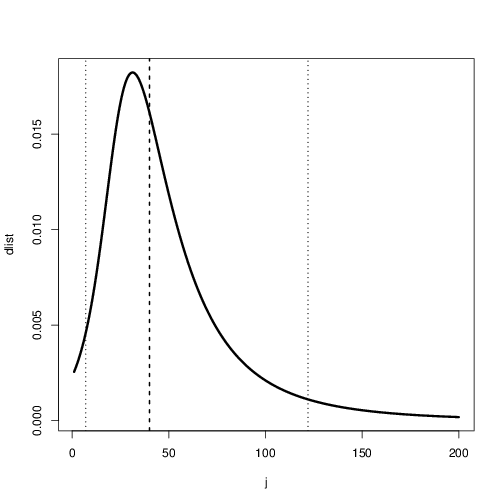

The whole thing seems to work pretty well, but there are limitations:

- the Johnson distribution is a simple, and natural, way to do this, but there are other options that might give different answers;
- I could say exactly the same thing about the way I chose to *constrain* the Johnson distribution
- assuming positivity and doing things on a log scale feels better for many epidemic predictions, but when things get near zero that gets a bit dicey. The classic trick of adding 1 to everything might be the best solution here, since 1 actually has a relevant meaning (it’s a single discrete case, not something with units)

Here are some sample distributions, generated on the linear scale. I used *90%* CIs for this picture, I held constant at (25, 400), and varied the median linearly between them. The middle curve is a normal distribution (since the Johnson matches the normal when there is no skewness)

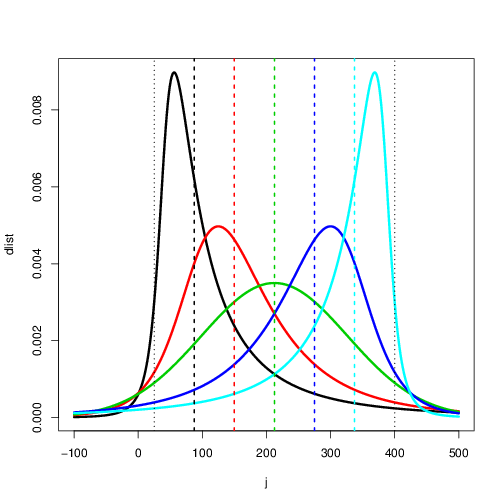

And here is a similar picture, generated on the log scale (with the median varied on the log scale). The middle curve is now lognormal.

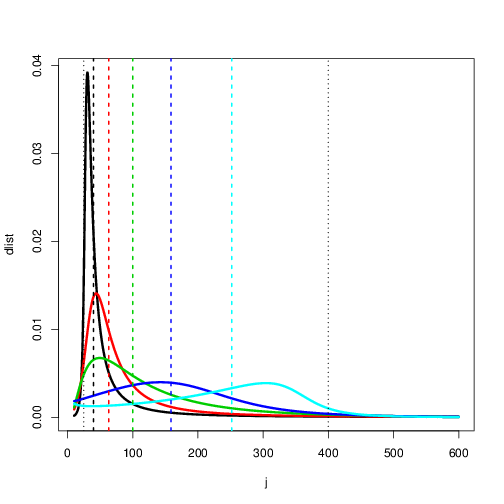

Since $q$ is passed as a separate parameter, the easiest way to implement this on a data frame would probably be to use `plyr`. I’m happy to keep working on this, if there is interest.